# ProblemSet2

Question 1

```python
#page 18 to determine h
#page 12-13 of lecture slides to program the one-sided and two-sided derivatives
class differentiator():
    def __init__(self,function):
        self.function=function
        self.epsilon=pow(10,-8)
    def h_calc(self,x):
        if abs(x)>=1:
            self.h=(abs(x)*self.epsilon)
        else:
            self.h=self.epsilon
    def one_sided(self,point,h):
        result=self.function(point+h)-self.function(point)
        result=result/h
        return(result)
    def two_sided(self,point,h):
        result=self.function(point+h)-self.function(point-h)
        result=result/(2*h)
        return(result)
```

Question 2

```python
import math
#absolute error- difference between estimated and actual

#Relative error=absolute error/actual value
x0=2
def function1(x):
    return(pow(x,2))
def function2(x):
    return(math.sin(x))
def function3(x):
    return(x*math.cos(x))
def function4(x):
    return(1/(1+math.cos(pow(x,2))))
def derivative1(x):
    return(2*x)
def derivative2(x):
    return(math.cos(x))
def derivative3(x):
    result=math.cos(x)-math.sin(x)*x
    return(result)
def derivative4(x):
    result=2*x*math.sin(pow(x,2))/pow((math.cos(pow(x,2))+1),2)
    return(result)
#derivatives calculated using wolfram alpha

def precision_calculator(function,derivative,x):
    obj=differentiator(function)
    obj.h_calc(x)
    perferct_h=obj.h
    h=[perferct_h,pow(10,-1),pow(10,-3),pow(10,-5),pow(10,-7),pow(10,-9),pow(10,-11)]
    for i in h:
        actual_value=derivative(x)
        prediction=obj.one_sided(x,i)
        abs_error_one_sided=prediction-actual_value
        relative_error=abs_error_one_sided/actual_value
        print("values for one-sided derivative")
        print([i,"h used"])
        print([prediction,"the prediction"])
        print([relative_error,"the realtive error"])
        prediction=obj.two_sided(x,i)
        abs_error_one_sided=prediction-actual_value
        relative_error=abs_error_one_sided/actual_value
        print("values for two-sided derivative")
        print([i,"h used"])
        print([prediction,"the prediction"])
        print([relative_error,"the realtive error"])
```

```python
precision_calculator(function1,derivative1,2)
```

```
values for one-sided derivative
[2e-08, 'h used']
[3.999999975690116, 'the prediction']
[-6.07747097092215e-09, 'the realtive error']
values for two-sided derivative
[2e-08, 'h used']
[3.9999999867923464, 'the prediction']
[-3.3019134093592584e-09, 'the realtive error']
values for one-sided derivative
[0.1, 'h used']
[4.100000000000001, 'the prediction']
[0.025000000000000355, 'the realtive error']
values for two-sided derivative
[0.1, 'h used']
[4.000000000000001, 'the prediction']
[2.220446049250313e-16, 'the realtive error']
values for one-sided derivative
[0.001, 'h used']
[4.000999999999699, 'the prediction']
[0.00024999999992481037, 'the realtive error']
values for two-sided derivative
[0.001, 'h used']
[3.9999999999995595, 'the prediction']
[-1.1013412404281553e-13, 'the realtive error']
values for one-sided derivative
[1e-05, 'h used']
[4.000010000027032, 'the prediction']
[2.500006758054951e-06, 'the realtive error']
values for two-sided derivative
[1e-05, 'h used']
[4.000000000026205, 'the prediction']
[6.551204023708124e-12, 'the realtive error']
values for one-sided derivative
[1e-07, 'h used']
[4.000000091153311, 'the prediction']
[2.278832766933192e-08, 'the realtive error']
values for two-sided derivative
[1e-07, 'h used']
[3.9999999956741306, 'the prediction']
[-1.0814673601089453e-09, 'the realtive error']
values for one-sided derivative
[1e-09, 'h used']
[4.000000330961484, 'the prediction']
[8.274037099909037e-08, 'the realtive error']
values for two-sided derivative
[1e-09, 'h used']
[4.000000330961484, 'the prediction']
[8.274037099909037e-08, 'the realtive error']
values for one-sided derivative
[1e-11, 'h used']
[4.000000330961484, 'the prediction']
[8.274037099909037e-08, 'the realtive error']
values for two-sided derivative
[1e-11, 'h used']
[4.000000330961484, 'the prediction']
[8.274037099909037e-08, 'the realtive error']
```

2-sided derivative when h=0.1 (quite a large value) outperforms all other options. For big h, two-sided derivative really outperforms one sided. For small h not much difference.

```python
precision_calculator(function2,derivative2,math.pi/3)
```

```
values for one-sided derivative
[1.0471975511965976e-08, 'h used']
[0.499999989254783, 'the prediction']
[-2.149043420995866e-08, 'the realtive error']
values for two-sided derivative
[1.0471975511965976e-08, 'h used']
[0.49999999985663196, 'the prediction']
[-2.8673630136921697e-10, 'the realtive error']
values for one-sided derivative
[0.1, 'h used']
[0.45590188541076104, 'the prediction']
[-0.08819622917847812, 'the realtive error']
values for two-sided derivative
[0.1, 'h used']
[0.4991670832341416, 'the prediction']
[-0.0016658335317170088, 'the realtive error']
values for one-sided derivative
[0.001, 'h used']
[0.49956690400077, 'the prediction']
[-0.0008661919984602748, 'the realtive error']
values for two-sided derivative
[0.001, 'h used']
[0.4999999166666047, 'the prediction']
[-1.6666679081289712e-07, 'the realtive error']
values for one-sided derivative
[1e-05, 'h used']
[0.499995669867026, 'the prediction']
[-8.660265948257083e-06, 'the realtive error']
values for two-sided derivative
[1e-05, 'h used']
[0.4999999999921733, 'the prediction']
[-1.565358953570239e-11, 'the realtive error']
values for one-sided derivative
[1e-07, 'h used']
[0.49999995699323563, 'the prediction']
[-8.601352896597801e-08, 'the realtive error']
values for two-sided derivative
[1e-07, 'h used']
[0.5000000002919336, 'the prediction']
[5.838669547841845e-10, 'the realtive error']
values for one-sided derivative
[1e-09, 'h used']
[0.5000000413701855, 'the prediction']
[8.274037077704576e-08, 'the realtive error']
values for two-sided derivative
[1e-09, 'h used']
[0.5000000413701855, 'the prediction']
[8.274037077704576e-08, 'the realtive error']
values for one-sided derivative
[1e-11, 'h used']
[0.5000000413701855, 'the prediction']
[8.274037077704576e-08, 'the realtive error']
values for two-sided derivative
[1e-11, 'h used']
[0.5000000413701855, 'the prediction']
[8.274037077704576e-08, 'the realtive error']
```

two sided derivative, when h=1e-05 outperfroms all other options

```python
precision_calculator(function3,derivative3,math.pi/3)
```

```
values for one-sided derivative
[1.0471975511965976e-08, 'h used']
[-0.40689969377614266, 'the prediction']
[2.8653337598682917e-08, 'the realtive error']
values for two-sided derivative
[1.0471975511965976e-08, 'h used']
[-0.40689968317429376, 'the prediction']
[2.598146688673105e-09, 'the realtive error']
values for one-sided derivative
[0.1, 'h used']
[-0.5205032599756421, 'the prediction']
[0.2791930857931647, 'the realtive error']
values for two-sided derivative
[0.1, 'h used']
[-0.407886855577721, 'the prediction']
[0.002426085602908293, 'the realtive error']
values for one-sided derivative
[0.001, 'h used']
[-0.40802760559244255, 'the prediction']
[0.0027719939948471963, 'the realtive error']
values for two-sided derivative
[0.001, 'h used']
[-0.4068997809670849, 'the prediction']
[2.429345132199263e-07, 'the realtive error']
values for one-sided derivative
[1e-05, 'h used']
[-0.40691096037104296, 'the prediction']
[2.7717529479465147e-05, 'the realtive error']
values for two-sided derivative
[1e-05, 'h used']
[-0.4068996821260384, 'the prediction']
[2.1945680257237945e-11, 'the realtive error']
values for one-sided derivative
[1e-07, 'h used']
[-0.40689979496910667, 'the prediction']
[2.7734599688444323e-07, 'the realtive error']
values for two-sided derivative
[1e-07, 'h used']
[-0.40689968228146967, 'the prediction']
[4.039348677394216e-10, 'the realtive error']
values for one-sided derivative
[1e-09, 'h used']
[-0.4068996251049839, 'the prediction']
[-1.4011346605699208e-07, 'the realtive error']
values for two-sided derivative
[1e-09, 'h used']
[-0.40689968061613513, 'the prediction']
[-3.688804965019748e-09, 'the realtive error']
values for one-sided derivative
[1e-11, 'h used']
[-0.40689673852511987, 'the prediction']
[-7.234195842839553e-06, 'the realtive error']
values for two-sided derivative
[1e-11, 'h used']
[-0.406902289640243, 'the prediction']
[6.40827026635768e-06, 'the realtive error']
```

```python
precision_calculator(function4,derivative4,math.pi/4)
```

```
values for one-sided derivative
[1e-08, 'h used']
[0.2756192052366657, 'the prediction']
[3.495290240573048e-08, 'the realtive error']
values for two-sided derivative
[1e-08, 'h used']
[0.2756191996855506, 'the prediction']
[1.48123780457288e-08, 'the realtive error']
values for one-sided derivative
[0.1, 'h used']
[0.3468025103165995, 'the prediction']
[0.25826689813057524, 'the realtive error']
values for two-sided derivative
[0.1, 'h used']
[0.2839891230297925, 'the prediction']
[0.030367723149712637, 'the realtive error']
values for one-sided derivative
[0.001, 'h used']
[0.276238665959716, 'the prediction']
[0.0022475588298047455, 'the realtive error']
values for two-sided derivative
[0.001, 'h used']
[0.2756200210787263, 'the prediction']
[2.9949864326917913e-06, 'the realtive error']
values for one-sided derivative
[1e-05, 'h used']
[0.2756253821289967, 'the prediction']
[2.2445918573510397e-05, 'the realtive error']
values for two-sided derivative
[1e-05, 'h used']
[0.2756191956831966, 'the prediction']
[2.910599821675898e-10, 'the realtive error']
values for one-sided derivative
[1e-07, 'h used']
[0.2756192574171479, 'the prediction']
[2.2427383138974623e-07, 'the realtive error']
values for two-sided derivative
[1e-07, 'h used']
[0.2756191952446585, 'the prediction']
[-1.3000414422725427e-09, 'the realtive error']
values for one-sided derivative
[1e-09, 'h used']
[0.2756191941344355, 'the prediction']
[-5.328146314272878e-09, 'the realtive error']
values for two-sided derivative
[1e-09, 'h used']
[0.2756191941344355, 'the prediction']
[-5.328146314272878e-09, 'the realtive error']
values for one-sided derivative
[1e-11, 'h used']
[0.27562396809344136, 'the prediction']
[1.731552280328717e-05, 'the realtive error']
values for two-sided derivative
[1e-11, 'h used']
[0.27562396809344136, 'the prediction']
[1.731552280328717e-05, 'the realtive error']
```

Two-sided derivative with h=1e-05 outperfroms all other options

Question 3

Solving the maximization problem for the youngsters who live alone:

1) Substituting the expression for consumption into utility:

$\frac{(w\epsilon h_a)^{1-\sigma}}{1-\sigma}-\psi \frac{h_A^{1+1/v}}{1+1/v}$  
2) Taking the frist derivative:  
$\frac{\partial U}{\partial h_a}=w\epsilon (w\epsilon h_A)^{-\sigma}-\psi h_A^{1/v}=(w\epsilon)^{1-\sigma}h_a^{-\sigma}-\psi h_A^{1/v}=0$  
$(w\epsilon)^{1-\sigma}h_a^{-\sigma}=\psi h_A^{1/v}$

$h_A^{-\sigma -1/v}=\frac{\psi}{(w\epsilon)^{1-\sigma}}$  
$h_A=(\frac{\psi}{(w\epsilon)^{1-\sigma}})^{\frac{1}{-\sigma -1/v}}$

Solving the problem for the youngsters living with parents:  
1) Expressing the utility as Taylor expansion around $h_A$:  
$U(h_T)=U(h_A)+U^{\prime}(h_A)(h_T-h_A)+U^{\prime \prime}(h_A)(h_T-h_A)^{2}$  
2) Taking the first derivative of the approximation: $\frac{\partial U}{\partial h_T}=U^{\prime}(h_A)+2U^{\prime \prime}(h_A)(h_T-h_A)=0$ $h_T=h_A-\frac{U^{\prime}(h_A)}{2U^{\prime \prime}(h_A)}$  
3) Finding the values for $U^{\prime}(h_A)$ and $U^{\prime \prime}(h_A)$:  
$U^{\prime}(h_A)=w\epsilon (w\epsilon h_A+\zeta)^{-\sigma}-\psi h_A^{1/v}$  
$U^{\prime \prime}(h_A)=-\sigma(w\epsilon)^2 (w\epsilon h_A+\zeta)^{-\sigma-1}-\frac{\psi}{v} h_A^{1/v-1}$  
Given this information, I can substitute the expressions into the utility function to obtain $\mu^{*}(\epsilon)$

The basic idea in my code is to use the following transformation:  
$\int^{\inf}_{0}f(x)dx=\int^{\inf}_{0}f(x)e^{x}e^{-x}dx=\int^{\inf}_{0}g(x)e^{-x}dx$ And use the Gauss- quadrature to evaluate the integral. Also I will use the idea that the integral inside the double integral is a normal CDF with $\mu^{*}(x)$ as its argument.

Defining the function that calculates $\mu^{*}(x)$:

```python
def h_a(psi,w,e,sigma,v,zeta):
    return(pow(psi/pow((w*e),(1-sigma)),1/(-sigma-1/v)))
def u_t_prime(psi,w,e,sigma,v,zeta):
    h=h_a(psi,w,e,sigma,v,zeta)
    result=w*e*pow(w*e*h+zeta,0-sigma)-pow(h,(1/v))*psi
    return(result)
def u_t_2prime(psi,w,e,sigma,v,zeta):
    h=h_a(psi,w,e,sigma,v,zeta)
    result=-sigma*pow(w*e,2)*pow(w*e*h+zeta,-sigma-1)-pow(h,(1/v)-1)*psi/v
    return(result)
def h_t(psi,w,e,sigma,v,zeta):
    h=h_a(psi,w,e,sigma,v,zeta)
    u_pr=u_t_prime(psi,w,e,sigma,v,zeta)
    u_2pr=u_t_2prime(psi,w,e,sigma,v,zeta)
    return(h-u_pr/(2*u_2pr))
def u_a(psi,w,e,sigma,v,zeta):
    h=h_a(psi,w,e,sigma,v,zeta)
    c=w*e*h
    result=pow(c,1-sigma)/(1-sigma)-psi*pow(h,1+1/v)/(1+1/v)
    return(result)


def u_t(psi,w,e,sigma,v,zeta):
    h=h_t(psi,w,e,sigma,v,zeta)
    c=w*e*h
    result=pow(c+zeta,1-sigma)/(1-sigma)-psi*pow(h,1+1/v)/(1+1/v)
    return(result)
def mu_star(psi,w,e,sigma,v,zeta):
    ua=u_a(psi,w,e,sigma,v,zeta)
    ut=u_t(psi,w,e,sigma,v,zeta)
    return(ut-ua)
```

Evaluating the integrals

To use Gauss-Hermitte quadrature I need to change the support of log-normal distribution from (0,inf) to (-inf,inf). To achieve that I am using change of variables $y=ln(x-\mu)$.  
$x=e^{y}+\mu$, $dy/dx=1/(x-\mu)$, $dx=(x-\mu)*dy$. The lognormal distribution after the change in variables transforms to: $\int_{0}^{inf}f(x)dx=\int_{0}^{inf} \frac{1}{x \sigma \sqrt{2 \pi}} e^{-\frac{ln(x-\mu)^2}{2 \sigma^2}}dx=\int_{-inf}^{inf}\frac{x-\mu}{x \sigma \sqrt{2 \pi}} e^{-\frac{y^2}{2 \sigma^2}}dy$

Defining the distributions of interest. Formulas are copied from Wikipedia

```python
#The function will calculate normal cdf using one of the internal packages.
import math
from scipy.stats import norm
from scipy.special import gamma
def norm_cdf(stddev,mean,x):
    dist=norm(scale=stddev,loc=mean)
    return(dist.cdf(x))
#Lognormal pdf
def lognormal_pdf(stddev,mean,x):
    result=math.exp(-pow(math.log(x)-mean,2)/(2*pow(stddev,2)))/(x*stddev*math.sqrt(2*math.pi))
    return(result)
    #Lognormal pdf transformed.
def trans_lognormal_pdf(stddev,mean,e):
    #random variable is from infinity to -infinity
    y=e
    x=math.exp(e)+mean
    result=(x-mean)*math.exp(-pow(y,2)/(2*pow(stddev,2)))/(x*stddev*math.sqrt(2*math.pi))
    return(result)
#Lognormal pdf transformed.
#Gamma pdf
def gamma_pdf(shape,scale,x):
    result=math.exp(-x/scale)*pow(x,shape-1)/(gamma(shape)*pow(scale,shape))
    return(result)
```

Fianlly the functions, that evaluates integrals using the 2 type of quadratures considered before. I use python a package to calculate nodes and weights for the quadratures considered:

```python
import numpy as np
#Gauss-Hermitte
def integrand_GH(function,e):
    return function(e)*math.exp(pow(e,2))
def integral_GH(function):
    ti, wi = np.polynomial.hermite.hermgauss(150)
    i=0
    result=0
    while i<len(ti):
        result+=wi[i]*integrand_GH(function,ti[i])
        i+=1
    return(result)
#Gauss-Laguerre
def integrand_GL(function,x):
    return function(x)*math.exp(x)

def integral_GL(function):
    ti, wi = np.polynomial.laguerre.laggauss(150)
    i=0
    result=0
    while i<len(ti):
        result+=wi[i]*integrand_GL(function,ti[i])
        i+=1
    return(result)
```

The function that does the plotting of $\mu^{*}(x)$:

```python
%matplotlib inline
import numpy as np
import matplotlib.pyplot as plt
def graph(formula, x_range):
    x = np.array(x_range)
    y = formula(x)  # <- note now we're calling the function 'formula' with x
    plt.plot(x, y)
    plt.show()
```

Question 2

Plotting

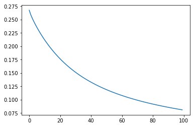

```python
def mu_star_q2(e):
    psi=4.193
    w=0.006
    sigma=0.436
    v=1.389
    zeta=0.035
    result=mu_star(psi,w,e,sigma,v,zeta)
    return(result)
def mu_star_q3(e):
    psi=4.483
    w=0.016
    sigma=0.430
    v=1.131
    zeta=0.222
    result=mu_star(psi,w,e,sigma,v,zeta)
    return(result)
graph(mu_star_q2,range(0, 100))
```

```python
#Compute using Gauss Hermit
def quest_2_fraction_hermit(e):
    mean1=0.084
    stddev1=0.135
    mean2=4.915
    stddev2=0.849
    x=math.exp(e)+mean2
    please_work=norm_cdf(stddev1,mean1,mu_star_q2(x))* \
    trans_lognormal_pdf(stddev2,mean2,e)
    return(please_work)
def quest_2_fraction_laguerre(e):
    mean1=0.084
    stddev1=0.135
    mean2=4.915
    stddev2=0.849
    please_work=norm_cdf(stddev1,mean1,mu_star_q2(e))* \
    lognormal_pdf(stddev2,mean2,e)
    return(please_work)
def quest_2_ht_hermit(e):
    mean1=0.084
    stddev1=0.135
    mean2=4.915
    stddev2=0.849
    psi=4.193
    w=0.006
    sigma=0.436
    v=1.389
    zeta=0.035
    ht=h_t(psi,w,e,sigma,v,zeta)
    x=math.exp(e)+mean2
    please_work=ht*norm_cdf(stddev1,mean1,mu_star_q2(x))* \
    trans_lognormal_pdf(stddev2,mean2,e)
    return(please_work)
def quest_2_ht_laguerre(e):
    mean1=0.084
    stddev1=0.135
    mean2=4.915
    stddev2=0.849
    psi=4.193
    w=0.006
    sigma=0.436
    v=1.389
    zeta=0.035
    ht=h_t(psi,w,e,sigma,v,zeta)
    please_work=ht*norm_cdf(stddev1,mean1,mu_star_q2(e))* \
    lognormal_pdf(stddev2,mean2,e)
    return(please_work)
def quest_2_ha_hermit(e):
    mean1=0.084
    stddev1=0.135
    mean2=4.915
    stddev2=0.849
    psi=4.193
    w=0.006
    sigma=0.436
    v=1.389
    zeta=0.035
    ha=h_a(psi,w,e,sigma,v,zeta)
    x=math.exp(e)+mean2
    please_work=ha*(1-norm_cdf(stddev1,mean1,mu_star_q2(x)))* \
    trans_lognormal_pdf(stddev2,mean2,e)
    return(please_work)
def quest_2_ha_laguerre(e):
    mean1=0.084
    stddev1=0.135
    mean2=4.915
    stddev2=0.849
    psi=4.193
    w=0.006
    sigma=0.436
    v=1.389
    zeta=0.035
    ha=h_a(psi,w,e,sigma,v,zeta)
    please_work=ha*(1-norm_cdf(stddev1,mean1,mu_star_q2(e)))* \
    lognormal_pdf(stddev2,mean2,e)
    return(please_work)
```

```python
import scipy.integrate as integrate
mean1=0.084
stddev1=0.135
mean2=4.915
stddev2=0.849
def trial_x(e):
    mean1=0.084
    stddev1=0.135
    mean2=4.915
    stddev2=0.849
    psi=4.193
    w=0.006
    sigma=0.436
    v=1.389
    zeta=0.035
    return(norm_cdf(stddev1,mean1,mu_star_q2(e))*\
           lognormal_pdf(stddev2,mean2,e))
def trial_ht(e):
    mean1=0.084
    stddev1=0.135
    mean2=4.915
    stddev2=0.849
    psi=4.193
    w=0.006
    sigma=0.436
    v=1.389
    zeta=0.035
    ht=h_t(psi,w,e,sigma,v,zeta)
    return(ht*norm_cdf(stddev1,mean1,mu_star_q2(e))*\
           lognormal_pdf(stddev2,mean2,e))
def trial_ha(e):
    mean1=0.084
    stddev1=0.135
    mean2=4.915
    stddev2=0.849
    psi=4.193
    w=0.006
    sigma=0.436
    v=1.389
    zeta=0.035
    ha=h_a(psi,w,e,sigma,v,zeta)
    return(ha*(1-norm_cdf(stddev1,mean1,mu_star_q2(e)))*\
           lognormal_pdf(stddev2,mean2,e))
```

Results for X. First is the output of Gauss-Hermitte quadrature. Second is the output of Gauss-Laguerre. The last is output grom the python package with estimated absolute error

```python
print(integral_GH(quest_2_fraction_hermit))
print(integral_GL(quest_2_fraction_laguerre))
integrate.quad(trial_x,a=0,b=np.inf)
```

```
0.168932372338
0.455660242474
```

```
(0.46951351405721076, 1.749573905555789e-11)
```

Gauss-Hermitte quadrature does not really work. It is either a mistake in code or something else

Results for $H_A$

```python
print(integral_GH(quest_2_ha_hermit))
print(integral_GL(quest_2_ha_laguerre))
integrate.quad(trial_ha,a=0,b=np.inf)
```

```
nan
0.143887035486
```

```
(0.16261544778092255, 2.1505454334156627e-09)
```

Results for $H_T$

```python
print(integral_GH(quest_2_ht_hermit))
print(integral_GL(quest_2_ht_laguerre))
integrate.quad(trial_ht,a=0,b=np.inf)
```

```
nan
0.109215851654
```

```
(0.1180244420333729, 7.057492030080184e-10)
```

The least productive and with the lowest disutility shocks live with parents, because for them extra consumption matters the most.

Question 3

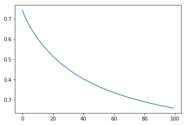

```python
graph(mu_star_q3,range(0, 100))
```

```python
def quest_3_fraction_laguerre(e):
    mean1=0.371
    stddev1=0.254
    shape=4.915
    scale=0.849
    please_work=norm_cdf(stddev1,mean1,mu_star_q2(e))* \
    gamma_pdf(shape,scale,e)
    return(please_work)
def quest_3_ht_laguerre(e):
    mean1=0.371
    stddev1=0.254
    shape=4.915
    scale=0.849
    psi=4.483
    w=0.016
    sigma=0.430
    v=1.131
    zeta=0.222
    ht=h_t(psi,w,e,sigma,v,zeta)
    please_work=ht*norm_cdf(stddev1,mean1,mu_star_q2(e))* \
    gamma_pdf(shape,scale,e)
    return(please_work)
def quest_3_ha_laguerre(e):
    mean1=0.371
    stddev1=0.254
    shape=4.915
    scale=0.849
    psi=4.483
    w=0.016
    sigma=0.430
    v=1.131
    zeta=0.222
    ha=h_a(psi,w,e,sigma,v,zeta)
    please_work=ha*(1-norm_cdf(stddev1,mean1,mu_star_q2(e)))* \
    gamma_pdf(shape,scale,e)
    return(please_work)
```

Results for x

```python
print(integral_GL(quest_3_fraction_laguerre))
integrate.quad(quest_3_fraction_laguerre,a=0,b=np.inf)
```

```
0.303481299445
```

```
(0.3034812994452911, 1.0591743223182766e-09)
```

```python
print(integral_GL(quest_3_ha_laguerre))
integrate.quad(quest_3_ha_laguerre,a=0,b=np.inf)
```

```
0.0673134804652
```

```
(0.06731348046512158, 1.1200956226957047e-08)
```

Results for $H_T$

```python
print(integral_GL(quest_3_ht_laguerre))
integrate.quad(quest_3_ht_laguerre,a=0,b=np.inf)
```

```
0.0162420312793
```

```
(0.01624203127927008, 1.8901434076077804e-09)
```